# Análisis_2

## **Análisis Comparativo del Desempeño de Preventistas: Octubre vs Julio 2024**

### 1. **Análisis descriptivo**

- **Promedios y totales:** Lo primero que haré será revisar los valores de las columnas **Volumen Act**, **Prom Actual**, **Volumen Mes Julio**, **Volumen Mes Septiem** y comparar los totales. Buscaré si hay algún preventista que destaque o que tenga un rendimiento consistentemente superior o inferior al promedio.
- **Tendencias de variación:** Observaré las columnas de variación porcentual (**% Var Volumen Mes-2** y **% Var Volumen Mes**) para identificar cambios en el rendimiento de un mes a otro. Si encuentro valores extremos, analizaré si representan áreas de mejora o si son buenos resultados a destacar.
- **Desviaciones actuales (% Dev Actual):** Evaluaré las desviaciones actuales para ver si los preventistas están dentro de los márgenes aceptables. Los valores altos pueden indicar problemas, mientras que los valores bajos pueden mostrar consistencia.

### 2. **Identificación de patrones**

- **Agrupación por rendimiento:** Clasificaré a los preventistas según su desempeño en función de las variaciones en el volumen de ventas. Identificaré si alguno muestra una tendencia de crecimiento constante o si está teniendo una reducción significativa en su desempeño.
- **Estabilidad en las ventas:** Compararé los promedios de cada mes (**Prom Actual**, **Prom Julio**, **Prom Septiem**) para ver si las ventas de cada preventista son estables o si fluctúan mucho entre meses.

### 3. **Comparación de meses**

- **Rendimiento Julio vs Septiembre:** Compararé el desempeño de cada preventista entre julio y septiembre, usando las columnas **Volumen Mes Julio** y **Volumen Mes Septiem**. Veré si hay una tendencia general de crecimiento o si las ventas están cayendo.
- **Rendimiento actual vs histórico:** Utilizaré la variación del volumen de ventas entre los meses más recientes y meses anteriores (columna **% Var Volumen Mes-2**) para entender qué preventistas están mejorando o empeorando con el tiempo.

### 4. **Análisis de rendimiento por preventista**

- **Mayores y menores resultados:** Identificaré quiénes son los mayores y los menores resultados en términos de:
  - **Volumen total** (columna **Volumen Act**).
  - **Desempeño en la variación de meses** (columna **% Var Volumen Mes**). Esto me ayudará a ver quién ha logrado el mayor crecimiento en comparación con el mes anterior.
  - **Desviaciones actuales** (columna **% Dev Actual**): Analizaré si alguno de los preventistas está fuera de los márgenes aceptables o si destaca por su consistencia.

### 5. **Visualización de datos**

- **Gráficos de barras:** Representaré el volumen de ventas de cada preventista en diferentes meses mediante gráficos de barras. Esto me permitirá identificar visualmente quién está destacando y quién necesita mejorar.
- **Gráfico de líneas:** Haré un gráfico de líneas para trazar las tendencias de crecimiento o decrecimiento en el volumen de ventas a lo largo del tiempo, resaltando **Julio** y **Septiembre**.
- **Mapa de calor:** Crearé un mapa de calor para las variaciones porcentuales, lo cual me ayudará a identificar rápidamente qué preventistas están experimentando mayores fluctuaciones.

### 6. **Análisis de correlaciones**

- **Relación entre las métricas:** Analizaré si existen correlaciones entre variables como **Prom Actual** y **Volumen Act**, o **% Var Volumen Mes-2** y **% Dev Actual**. Esto me permitirá ver si hay patrones recurrentes en el desempeño de los preventistas.

### 7. **Conclusiones y recomendaciones**

- **Detectar áreas de mejora:** Identificaré preventistas con baja variación positiva o con resultados consistentemente inferiores al promedio. De esta manera, podré enfocar estrategias de mejora en ellos.
- **Destacar buenos resultados:** Si algún preventista muestra un crecimiento constante o un buen desempeño, investigaré qué está haciendo bien para replicar esos métodos con otros equipos.

Estas pautas me permitirán obtener insights profundos sobre el rendimiento de los preventistas y determinar qué áreas necesitan atención.

```python
import pandas as pd
import numpy as np
import matplotlib.pyplot as plt
import seaborn as sns
```

```python
data = {
    "Nombre (preventista)": ["REINAGA MARIANO", "DÍAZ GUSTAVO", "GÓMEZ RODOLFO",
                             "CASAS DANIEL", "DOUPONT JUAN", None, None],
    "Volumen Act": [80794, 54055, 49615, 40016, 35712, 260191, 260191],
    "Prom Actual": [3366, 2252, 2067, 1667, 1488, 10841, 10841],
    "Volumen Mes Julio": [89264, 56019, 51900, 40728, 33132, 271033, 271033],
    "Prom Julio": [3719, 2334, 2163, 1697, 1380, 11293, 11293],
    "% Var Volumen Mes-2": [-9.5, -3.5, -4.4, -1.7, 7.8, -4.0, -4.0],
    "Volumen Mes Septiem": [78687, 51929, 49196, 36466, 30330, 246607, 246607],
    "Prom Septiem": [2636, 1667, 1644, 1358, 861, 8167, 8167],
    "% Var Volumen Mes": [2.7, 4.1, 0.9, 9.7, 17.7, 5.5, 5.5],
    "% Dev Actual": [1.1, 1.1, 1.2, 3.2, 1.9, 1.5, 1.5]
}
```

```python
data = pd.DataFrame(data)
data
```

|  | Nombre (preventista) | Volumen Act | Prom Actual | Volumen Mes Julio | Prom Julio | % Var Volumen Mes-2 | Volumen Mes Septiem | Prom Septiem | % Var Volumen Mes | % Dev Actual |
| --- | --- | --- | --- | --- | --- | --- | --- | --- | --- | --- |
| 0 | REINAGA MARIANO | 80794 | 3366 | 89264 | 3719 | -9.5 | 78687 | 2636 | 2.7 | 1.1 |
| 1 | DÍAZ GUSTAVO | 54055 | 2252 | 56019 | 2334 | -3.5 | 51929 | 1667 | 4.1 | 1.1 |
| 2 | GÓMEZ RODOLFO | 49615 | 2067 | 51900 | 2163 | -4.4 | 49196 | 1644 | 0.9 | 1.2 |
| 3 | CASAS DANIEL | 40016 | 1667 | 40728 | 1697 | -1.7 | 36466 | 1358 | 9.7 | 3.2 |
| 4 | DOUPONT JUAN | 35712 | 1488 | 33132 | 1380 | 7.8 | 30330 | 861 | 17.7 | 1.9 |
| 5 | None | 260191 | 10841 | 271033 | 11293 | -4.0 | 246607 | 8167 | 5.5 | 1.5 |
| 6 | None | 260191 | 10841 | 271033 | 11293 | -4.0 | 246607 | 8167 | 5.5 | 1.5 |

```python
data.info()
```

```
<class 'pandas.core.frame.DataFrame'>
RangeIndex: 7 entries, 0 to 6
Data columns (total 10 columns):
 #   Column                Non-Null Count  Dtype
---  ------                --------------  -----
 0   Nombre (preventista)  5 non-null      object
 1   Volumen Act           7 non-null      int64
 2   Prom Actual           7 non-null      int64
 3   Volumen Mes Julio     7 non-null      int64
 4   Prom Julio            7 non-null      int64
 5   % Var Volumen Mes-2   7 non-null      float64
 6   Volumen Mes Septiem   7 non-null      int64
 7   Prom Septiem          7 non-null      int64
 8   % Var Volumen Mes     7 non-null      float64
 9   % Dev Actual          7 non-null      float64
dtypes: float64(3), int64(6), object(1)
memory usage: 688.0+ bytes
```

### 1. **Análisis descriptivo**

- **Promedios y totales:** Lo primero que haré será revisar los valores de las columnas **Volumen Act**, **Prom Actual**, **Volumen Mes Julio**, **Volumen Mes Septiem** y comparar los totales. Buscaré si hay algún preventista que destaque o que tenga un rendimiento consistentemente superior o inferior al promedio.

```python
data2 = data.copy()
data2
```

|  | Nombre (preventista) | Volumen Act | Prom Actual | Volumen Mes Julio | Prom Julio | % Var Volumen Mes-2 | Volumen Mes Septiem | Prom Septiem | % Var Volumen Mes | % Dev Actual |
| --- | --- | --- | --- | --- | --- | --- | --- | --- | --- | --- |
| 0 | REINAGA MARIANO | 80794 | 3366 | 89264 | 3719 | -9.5 | 78687 | 2636 | 2.7 | 1.1 |
| 1 | DÍAZ GUSTAVO | 54055 | 2252 | 56019 | 2334 | -3.5 | 51929 | 1667 | 4.1 | 1.1 |
| 2 | GÓMEZ RODOLFO | 49615 | 2067 | 51900 | 2163 | -4.4 | 49196 | 1644 | 0.9 | 1.2 |
| 3 | CASAS DANIEL | 40016 | 1667 | 40728 | 1697 | -1.7 | 36466 | 1358 | 9.7 | 3.2 |
| 4 | DOUPONT JUAN | 35712 | 1488 | 33132 | 1380 | 7.8 | 30330 | 861 | 17.7 | 1.9 |
| 5 | None | 260191 | 10841 | 271033 | 11293 | -4.0 | 246607 | 8167 | 5.5 | 1.5 |
| 6 | None | 260191 | 10841 | 271033 | 11293 | -4.0 | 246607 | 8167 | 5.5 | 1.5 |

```python
data2.dropna(inplace=True)
data2
```

|  | Nombre (preventista) | Volumen Act | Prom Actual | Volumen Mes Julio | Prom Julio | % Var Volumen Mes-2 | Volumen Mes Septiem | Prom Septiem | % Var Volumen Mes | % Dev Actual |
| --- | --- | --- | --- | --- | --- | --- | --- | --- | --- | --- |
| 0 | REINAGA MARIANO | 80794 | 3366 | 89264 | 3719 | -9.5 | 78687 | 2636 | 2.7 | 1.1 |
| 1 | DÍAZ GUSTAVO | 54055 | 2252 | 56019 | 2334 | -3.5 | 51929 | 1667 | 4.1 | 1.1 |
| 2 | GÓMEZ RODOLFO | 49615 | 2067 | 51900 | 2163 | -4.4 | 49196 | 1644 | 0.9 | 1.2 |
| 3 | CASAS DANIEL | 40016 | 1667 | 40728 | 1697 | -1.7 | 36466 | 1358 | 9.7 | 3.2 |
| 4 | DOUPONT JUAN | 35712 | 1488 | 33132 | 1380 | 7.8 | 30330 | 861 | 17.7 | 1.9 |

```python
data_promedio_volumen = data2.loc[:,['Nombre (preventista)','Volumen Act','Volumen Mes Julio','Volumen Mes Septiem']]
data_promedio_volumen
```

|  | Nombre (preventista) | Volumen Act | Volumen Mes Julio | Volumen Mes Septiem |
| --- | --- | --- | --- | --- |
| 0 | REINAGA MARIANO | 80794 | 89264 | 78687 |
| 1 | DÍAZ GUSTAVO | 54055 | 56019 | 51929 |
| 2 | GÓMEZ RODOLFO | 49615 | 51900 | 49196 |
| 3 | CASAS DANIEL | 40016 | 40728 | 36466 |
| 4 | DOUPONT JUAN | 35712 | 33132 | 30330 |

```python
data_promedio_volumen['Promedio'] = ((data_promedio_volumen['Volumen Act'] + data_promedio_volumen['Volumen Mes Julio'] + data_promedio_volumen['Volumen Mes Septiem']) / 3).round(2)
data_promedio_volumen
```

|  | Nombre (preventista) | Volumen Act | Volumen Mes Julio | Volumen Mes Septiem | Promedio |
| --- | --- | --- | --- | --- | --- |
| 0 | REINAGA MARIANO | 80794 | 89264 | 78687 | 82915.0 |
| 1 | DÍAZ GUSTAVO | 54055 | 56019 | 51929 | 54001.0 |
| 2 | GÓMEZ RODOLFO | 49615 | 51900 | 49196 | 50237.0 |
| 3 | CASAS DANIEL | 40016 | 40728 | 36466 | 39070.0 |
| 4 | DOUPONT JUAN | 35712 | 33132 | 30330 | 33058.0 |

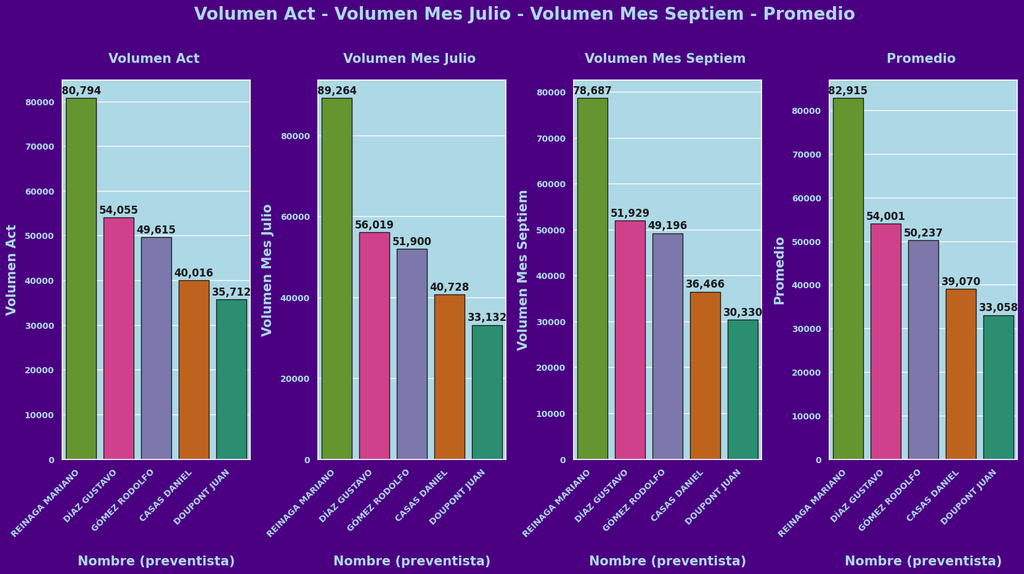

```python
sns.set_style('darkgrid')
sns.set_theme(rc={'axes.facecolor':'lightblue', 'figure.facecolor':'indigo'})
plt.figure(figsize=(20,8))
plt.suptitle('Volumen Act - Volumen Mes Julio - Volumen Mes Septiem - Promedio', color='lightblue', size=20, weight='bold', y=1.03)
plt.subplot(1,4,1)
ax = sns.barplot(x='Nombre (preventista)', y='Volumen Act', data=data_promedio_volumen, edgecolor='k', hue='Volumen Act', palette='Dark2')
plt.title('Volumen Act ', color='lightblue', size=15, weight='bold', pad=20)
plt.xlabel('Nombre (preventista)', color='lightblue', size=15, weight='bold', labelpad=20)
plt.ylabel('Volumen Act', color='lightblue', size=15, weight='bold', labelpad=7)
plt.xticks(color='lightblue', size=10, weight='bold', rotation=45, ha='right')
plt.yticks(color='lightblue', size=10, weight='bold')
for container in ax.containers:
    ax.bar_label(container,
                label_type='edge',
                padding=2,
                color='k',
                fontsize=12,
                fontweight='bold',
                fmt='{:,.0f}')
plt.legend().remove()
plt.subplot(1,4,2)
ax = sns.barplot(x='Nombre (preventista)', y='Volumen Mes Julio', data=data_promedio_volumen, edgecolor='k', hue='Volumen Mes Julio', palette='Dark2')
plt.title('Volumen Mes Julio ', color='lightblue', size=15, weight='bold', pad=20)
plt.xlabel('Nombre (preventista)', color='lightblue', size=15, weight='bold', labelpad=20)
plt.ylabel('Volumen Mes Julio', color='lightblue', size=15, weight='bold', labelpad=7)
plt.xticks(color='lightblue', size=10, weight='bold', rotation=45, ha='right')
plt.yticks(color='lightblue', size=10, weight='bold')
for container in ax.containers:
    ax.bar_label(container,
                label_type='edge',
                padding=2,
                color='k',
                fontsize=12,
                fontweight='bold',
                fmt='{:,.0f}')
plt.legend().remove()
plt.subplot(1,4,3)
ax = sns.barplot(x='Nombre (preventista)', y='Volumen Mes Septiem', data=data_promedio_volumen, edgecolor='k', hue='Volumen Mes Septiem', palette='Dark2')
plt.title('Volumen Mes Septiem ', color='lightblue', size=15, weight='bold', pad=20)
plt.xlabel('Nombre (preventista)', color='lightblue', size=15, weight='bold', labelpad=20)
plt.ylabel('Volumen Mes Septiem', color='lightblue', size=15, weight='bold', labelpad=7)
plt.xticks(color='lightblue', size=10, weight='bold', rotation=45, ha='right')
plt.yticks(color='lightblue', size=10, weight='bold')
for container in ax.containers:
    ax.bar_label(container,
                label_type='edge',
                padding=2,
                color='k',
                fontsize=12,
                fontweight='bold',
                fmt='{:,.0f}')
plt.legend().remove()
plt.subplot(1,4,4)
ax = sns.barplot(x='Nombre (preventista)', y='Promedio', data=data_promedio_volumen, edgecolor='k', hue='Promedio', palette='Dark2')
plt.title('Promedio ', color='lightblue', size=15, weight='bold', pad=20)
plt.xlabel('Nombre (preventista)', color='lightblue', size=15, weight='bold', labelpad=20)
plt.ylabel('Promedio', color='lightblue', size=15, weight='bold', labelpad=7)
plt.xticks(color='lightblue', size=10, weight='bold', rotation=45, ha='right')
plt.yticks(color='lightblue', size=10, weight='bold')
for container in ax.containers:
    ax.bar_label(container,
                label_type='edge',
                padding=2,
                color='k',
                fontsize=12,
                fontweight='bold',
                fmt='{:,.0f}')
plt.legend().remove()
plt.subplots_adjust(wspace=0.36)
plt.show()
```

- **Tendencias de variación:** Observaré las columnas de variación porcentual (**% Var Volumen Mes-2** y **% Var Volumen Mes**) para identificar cambios en el rendimiento de un mes a otro. Si encuentro valores extremos, analizaré si representan áreas de mejora o si son buenos resultados a destacar.

```python
data.sample()
```

|  | Nombre (preventista) | Volumen Act | Prom Actual | Volumen Mes Julio | Prom Julio | % Var Volumen Mes-2 | Volumen Mes Septiem | Prom Septiem | % Var Volumen Mes | % Dev Actual |
| --- | --- | --- | --- | --- | --- | --- | --- | --- | --- | --- |
| 4 | DOUPONT JUAN | 35712 | 1488 | 33132 | 1380 | 7.8 | 30330 | 861 | 17.7 | 1.9 |

```python
data_variacion = data.loc[:,['Nombre (preventista)','% Var Volumen Mes-2','% Var Volumen Mes']]
data_variacion
```

|  | Nombre (preventista) | % Var Volumen Mes-2 | % Var Volumen Mes |
| --- | --- | --- | --- |
| 0 | REINAGA MARIANO | -9.5 | 2.7 |
| 1 | DÍAZ GUSTAVO | -3.5 | 4.1 |
| 2 | GÓMEZ RODOLFO | -4.4 | 0.9 |
| 3 | CASAS DANIEL | -1.7 | 9.7 |
| 4 | DOUPONT JUAN | 7.8 | 17.7 |
| 5 | None | -4.0 | 5.5 |
| 6 | None | -4.0 | 5.5 |

```python
promedio_variacion = data_variacion['% Var Volumen Mes-2'] + data_variacion['% Var Volumen Mes'] / 2
data_variacion['Promedio Variacion'] = promedio_variacion
data_variacion
```

|  | Nombre (preventista) | % Var Volumen Mes-2 | % Var Volumen Mes | Promedio Variacion |
| --- | --- | --- | --- | --- |
| 0 | REINAGA MARIANO | -9.5 | 2.7 | -8.15 |
| 1 | DÍAZ GUSTAVO | -3.5 | 4.1 | -1.45 |
| 2 | GÓMEZ RODOLFO | -4.4 | 0.9 | -3.95 |
| 3 | CASAS DANIEL | -1.7 | 9.7 | 3.15 |
| 4 | DOUPONT JUAN | 7.8 | 17.7 | 16.65 |
| 5 | None | -4.0 | 5.5 | -1.25 |
| 6 | None | -4.0 | 5.5 | -1.25 |

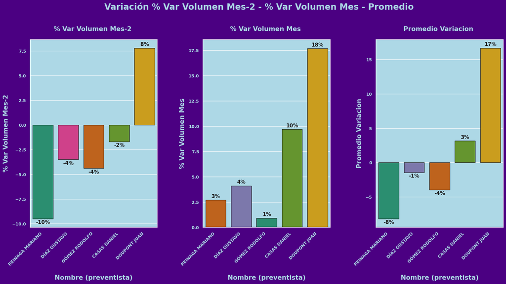

```python
sns.set_style('darkgrid')
sns.set_theme(rc={'axes.facecolor':'lightblue', 'figure.facecolor':'indigo'})
plt.figure(figsize=(20,8))
plt.suptitle('Variación % Var Volumen Mes-2 - % Var Volumen Mes - Promedio', color='lightblue', size=20, weight='bold', y=1.03)
plt.subplot(1,3,1)
ax = sns.barplot(x='Nombre (preventista)', y='% Var Volumen Mes-2', data=data_variacion, edgecolor='k', hue='% Var Volumen Mes-2', palette='Dark2')
plt.title('% Var Volumen Mes-2 ', color='lightblue', size=15, weight='bold', pad=20)
plt.xlabel('Nombre (preventista)', color='lightblue', size=15, weight='bold', labelpad=20)
plt.ylabel('% Var Volumen Mes-2', color='lightblue', size=15, weight='bold', labelpad=7)
plt.xticks(color='lightblue', size=10, weight='bold', rotation=45, ha='right')
plt.yticks(color='lightblue', size=10, weight='bold')
for container in ax.containers:
    ax.bar_label(container,
                label_type='edge',
                padding=2,
                color='k',
                fontsize=12,
                fontweight='bold',
                fmt='{:,.0f}%')
plt.legend().remove()
plt.subplot(1,3,2)
ax = sns.barplot(x='Nombre (preventista)', y='% Var Volumen Mes', data=data_variacion, edgecolor='k', hue='% Var Volumen Mes', palette='Dark2')
plt.title('% Var Volumen Mes ', color='lightblue', size=15, weight='bold', pad=20)
plt.xlabel('Nombre (preventista)', color='lightblue', size=15, weight='bold', labelpad=20)
plt.ylabel('% Var Volumen Mes', color='lightblue', size=15, weight='bold', labelpad=7)
plt.xticks(color='lightblue', size=10, weight='bold', rotation=45, ha='right')
plt.yticks(color='lightblue', size=10, weight='bold')
for container in ax.containers:
    ax.bar_label(container,
                label_type='edge',
                padding=2,
                color='k',
                fontsize=12,
                fontweight='bold',
                fmt='{:,.0f}%')
plt.legend().remove()
plt.subplot(1,3,3)
ax = sns.barplot(x='Nombre (preventista)', y='Promedio Variacion', data=data_variacion, edgecolor='k', hue='Promedio Variacion', palette='Dark2')
plt.title('Promedio Variacion ', color='lightblue', size=15, weight='bold', pad=20)
plt.xlabel('Nombre (preventista)', color='lightblue', size=15, weight='bold', labelpad=20)
plt.ylabel('Promedio Variacion', color='lightblue', size=15, weight='bold', labelpad=7)
plt.xticks(color='lightblue', size=10, weight='bold', rotation=45, ha='right')
plt.yticks(color='lightblue', size=10, weight='bold')
for container in ax.containers:
    ax.bar_label(container,
                label_type='edge',
                padding=2,
                color='k',
                fontsize=12,
                fontweight='bold',
                fmt='{:,.0f}%')
plt.legend().remove()
plt.subplots_adjust(wspace=0.36)
plt.show()
```

- **Desviaciones actuales (% Dev Actual):** Evaluaré las desviaciones actuales para ver si los preventistas están dentro de los márgenes aceptables. Los valores altos pueden indicar problemas, mientras que los valores bajos pueden mostrar consistencia.

```python
data.sample()
```

|  | Nombre (preventista) | Volumen Act | Prom Actual | Volumen Mes Julio | Prom Julio | % Var Volumen Mes-2 | Volumen Mes Septiem | Prom Septiem | % Var Volumen Mes | % Dev Actual |
| --- | --- | --- | --- | --- | --- | --- | --- | --- | --- | --- |
| 4 | DOUPONT JUAN | 35712 | 1488 | 33132 | 1380 | 7.8 | 30330 | 861 | 17.7 | 1.9 |

```python
desviaciones = data.loc[:,['Nombre (preventista)','% Dev Actual']]
desviaciones
```

|  | Nombre (preventista) | % Dev Actual |
| --- | --- | --- |
| 0 | REINAGA MARIANO | 1.1 |
| 1 | DÍAZ GUSTAVO | 1.1 |
| 2 | GÓMEZ RODOLFO | 1.2 |
| 3 | CASAS DANIEL | 3.2 |
| 4 | DOUPONT JUAN | 1.9 |
| 5 | None | 1.5 |
| 6 | None | 1.5 |

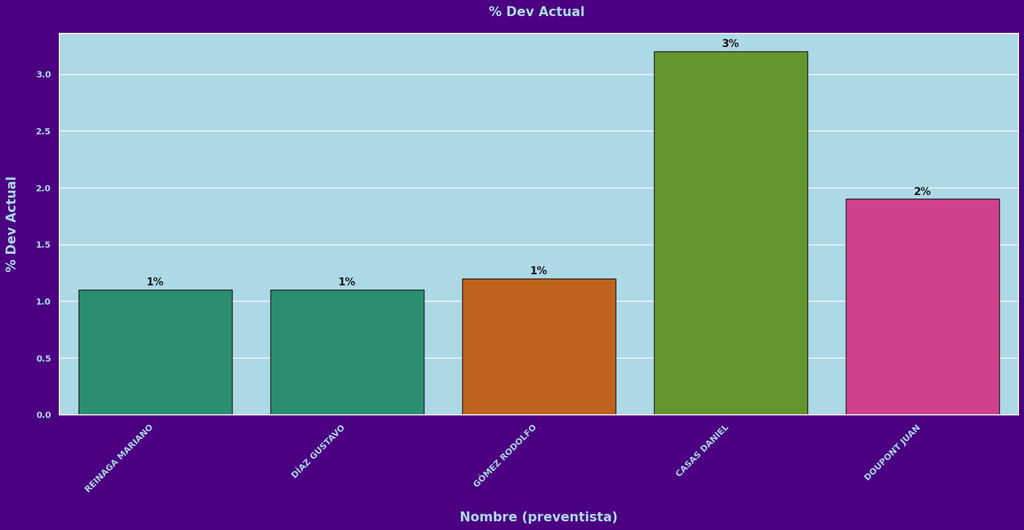

```python
sns.set_style('darkgrid')
sns.set_theme(rc={'axes.facecolor':'lightblue', 'figure.facecolor':'indigo'})
plt.figure(figsize=(20,8))
ax = sns.barplot(x='Nombre (preventista)', y='% Dev Actual', data=desviaciones, edgecolor='k', hue='% Dev Actual', palette='Dark2')
plt.title('% Dev Actual ', color='lightblue', size=15, weight='bold', pad=20)
plt.xlabel('Nombre (preventista)', color='lightblue', size=15, weight='bold', labelpad=20)
plt.ylabel('% Dev Actual', color='lightblue', size=15, weight='bold', labelpad=20)
plt.xticks(color='lightblue', size=10, weight='bold', rotation=45, ha='right')
plt.yticks(color='lightblue', size=10, weight='bold')
for container in ax.containers:
    ax.bar_label(container,
                label_type='edge',
                padding=2,
                color='k',
                fontsize=12,
                fontweight='bold',
                fmt='{:,.0f}%')
plt.legend().remove()
plt.show()
```

### 2. **Identificación de patrones**

- **Agrupación por rendimiento:** Clasificaré a los preventistas según su desempeño en función de las variaciones en el volumen de ventas. Identificaré si alguno muestra una tendencia de crecimiento constante o si está teniendo una reducción significativa en su desempeño.

```python
data.sample()
```

|  | Nombre (preventista) | Volumen Act | Prom Actual | Volumen Mes Julio | Prom Julio | % Var Volumen Mes-2 | Volumen Mes Septiem | Prom Septiem | % Var Volumen Mes | % Dev Actual |
| --- | --- | --- | --- | --- | --- | --- | --- | --- | --- | --- |
| 2 | GÓMEZ RODOLFO | 49615 | 2067 | 51900 | 2163 | -4.4 | 49196 | 1644 | 0.9 | 1.2 |

```python
data_rendimiento = data.loc[:,['Nombre (preventista)','Volumen Act','% Var Volumen Mes']]
data_rendimiento
```

|  | Nombre (preventista) | Volumen Act | % Var Volumen Mes |
| --- | --- | --- | --- |
| 0 | REINAGA MARIANO | 80794 | 2.7 |
| 1 | DÍAZ GUSTAVO | 54055 | 4.1 |
| 2 | GÓMEZ RODOLFO | 49615 | 0.9 |
| 3 | CASAS DANIEL | 40016 | 9.7 |
| 4 | DOUPONT JUAN | 35712 | 17.7 |
| 5 | None | 260191 | 5.5 |
| 6 | None | 260191 | 5.5 |

```python
data_rendimiento.dropna(inplace=True)
data_rendimiento
```

|  | Nombre (preventista) | Volumen Act | % Var Volumen Mes |
| --- | --- | --- | --- |
| 0 | REINAGA MARIANO | 80794 | 2.7 |
| 1 | DÍAZ GUSTAVO | 54055 | 4.1 |
| 2 | GÓMEZ RODOLFO | 49615 | 0.9 |
| 3 | CASAS DANIEL | 40016 | 9.7 |
| 4 | DOUPONT JUAN | 35712 | 17.7 |

```python
# Clasificación basada en la variación de volumen de ventas
def clasificar_var(row):
    if row["% Var Volumen Mes"] > 2:
        return "Creciente"
    elif row["% Var Volumen Mes"] < -2:
        return "Decreciente"
    else:
        return "Constante"

data_rendimiento['Clasificación'] = data_rendimiento.apply(clasificar_var, axis=1)
data_rendimiento[['Nombre (preventista)', 'Volumen Act', '% Var Volumen Mes', 'Clasificación']].sort_values(by='Volumen Act', ascending=False)
```

|  | Nombre (preventista) | Volumen Act | % Var Volumen Mes | Clasificación |
| --- | --- | --- | --- | --- |
| 0 | REINAGA MARIANO | 80794 | 2.7 | Creciente |
| 1 | DÍAZ GUSTAVO | 54055 | 4.1 | Creciente |
| 2 | GÓMEZ RODOLFO | 49615 | 0.9 | Constante |
| 3 | CASAS DANIEL | 40016 | 9.7 | Creciente |
| 4 | DOUPONT JUAN | 35712 | 17.7 | Creciente |

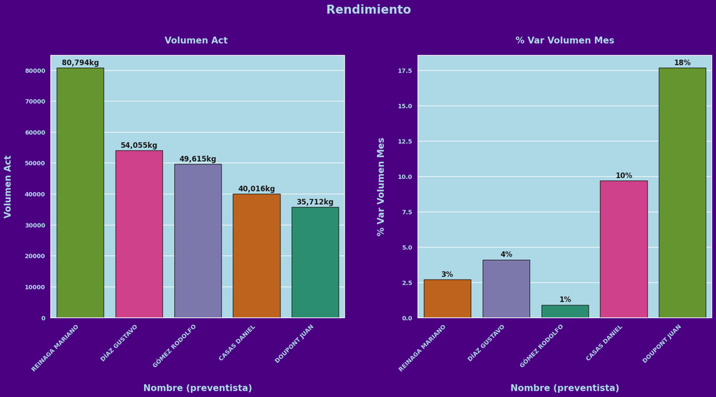

```python
sns.set_style('darkgrid')
sns.set_theme(rc={'axes.facecolor':'lightblue', 'figure.facecolor':'indigo'})
plt.figure(figsize=(20,8))
plt.suptitle('Rendimiento ', color='lightblue', size=20, weight='bold', y=1.03)
plt.subplot(1,2,1)
ax = sns.barplot(x='Nombre (preventista)', y='Volumen Act', data=data_rendimiento, edgecolor='k', hue='Volumen Act', palette='Dark2')
for container in ax.containers:
    ax.bar_label(container,
                label_type='edge',
                padding=2,
                color='k',
                fontsize=12,
                fontweight='bold',
                fmt='{:,.0f}kg')
plt.title('Volumen Act ', color='lightblue', size=15, weight='bold', pad=20)
plt.xlabel('Nombre (preventista)', color='lightblue', size=15, weight='bold', labelpad=20)
plt.ylabel('Volumen Act', color='lightblue', size=15, weight='bold', labelpad=20)
plt.xticks(color='lightblue', size=10, weight='bold', rotation=45, ha='right')
plt.yticks(color='lightblue', size=10, weight='bold')
plt.legend().remove()
plt.subplot(1,2,2)
ax = sns.barplot(x='Nombre (preventista)', y='% Var Volumen Mes', data=data_rendimiento, edgecolor='k', hue='% Var Volumen Mes', palette='Dark2')
for container in ax.containers:
    ax.bar_label(container,
                label_type='edge',
                padding=2,
                color='k',
                fontsize=12,
                fontweight='bold',
                fmt='{:,.0f}%')
plt.title('% Var Volumen Mes', color='lightblue', size=15, weight='bold', pad=20)
plt.xlabel('Nombre (preventista)', color='lightblue', size=15, weight='bold', labelpad=20)
plt.ylabel('% Var Volumen Mes', color='lightblue', size=15, weight='bold', labelpad=20)
plt.xticks(color='lightblue', size=10, weight='bold', rotation=45, ha='right')
plt.yticks(color='lightblue', size=10, weight='bold')
plt.legend().remove()
plt.subplots_adjust(wspace=0.25)
plt.show()
```

### Análisis de Rendimiento por Preventista:

[output not shown]

### 3. **Comparación de meses**

- **Rendimiento Julio vs Septiembre:** Compararo el desempeño de cada preventista entre julio y septiembre, usando las columnas **Volumen Mes Julio** y **Volumen Mes Septiem**. Veré si hay una tendencia general de crecimiento o si las ventas están cayendo.
- **Rendimiento actual vs histórico:** Utilizaré la variación del volumen de ventas entre los meses más recientes y meses anteriores (columna **% Var Volumen Mes-2**) para entender qué preventistas están mejorando o empeorando con el tiempo.

```python
data2.sample()
```

|  | Nombre (preventista) | Volumen Act | Prom Actual | Volumen Mes Julio | Prom Julio | % Var Volumen Mes-2 | Volumen Mes Septiem | Prom Septiem | % Var Volumen Mes | % Dev Actual |
| --- | --- | --- | --- | --- | --- | --- | --- | --- | --- | --- |
| 1 | DÍAZ GUSTAVO | 54055 | 2252 | 56019 | 2334 | -3.5 | 51929 | 1667 | 4.1 | 1.1 |

```python
rendimiento_julio_sep = data2.loc[:,['Nombre (preventista)','Volumen Mes Julio','Volumen Mes Septiem']]
rendimiento_julio_sep
```

|  | Nombre (preventista) | Volumen Mes Julio | Volumen Mes Septiem |
| --- | --- | --- | --- |
| 0 | REINAGA MARIANO | 89264 | 78687 |
| 1 | DÍAZ GUSTAVO | 56019 | 51929 |
| 2 | GÓMEZ RODOLFO | 51900 | 49196 |
| 3 | CASAS DANIEL | 40728 | 36466 |
| 4 | DOUPONT JUAN | 33132 | 30330 |

```python
rendimiento_julio_sep['Promedio'] = ((rendimiento_julio_sep['Volumen Mes Julio'] + rendimiento_julio_sep['Volumen Mes Septiem']) / 2).round(2)
rendimiento_julio_sep_promedio = rendimiento_julio_sep
rendimiento_julio_sep_promedio
```

|  | Nombre (preventista) | Volumen Mes Julio | Volumen Mes Septiem | Promedio |
| --- | --- | --- | --- | --- |
| 0 | REINAGA MARIANO | 89264 | 78687 | 83975.5 |
| 1 | DÍAZ GUSTAVO | 56019 | 51929 | 53974.0 |
| 2 | GÓMEZ RODOLFO | 51900 | 49196 | 50548.0 |
| 3 | CASAS DANIEL | 40728 | 36466 | 38597.0 |
| 4 | DOUPONT JUAN | 33132 | 30330 | 31731.0 |

```python
rendimiento_julio_sep_promedio.describe()
```

|  | Volumen Mes Julio | Volumen Mes Septiem | Promedio |
| --- | --- | --- | --- |
| count | 5.000000 | 5.000000 | 5.000000 |
| mean | 54208.600000 | 49321.600000 | 51765.100000 |
| std | 21583.778024 | 18675.440752 | 20116.128232 |
| min | 33132.000000 | 30330.000000 | 31731.000000 |
| 25% | 40728.000000 | 36466.000000 | 38597.000000 |
| 50% | 51900.000000 | 49196.000000 | 50548.000000 |
| 75% | 56019.000000 | 51929.000000 | 53974.000000 |
| max | 89264.000000 | 78687.000000 | 83975.500000 |

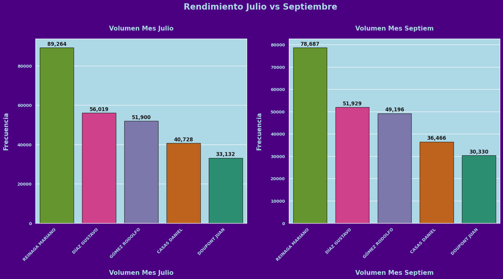

```python
sns.set_style('darkgrid')
sns.set_theme(rc={'axes.facecolor':'lightblue', 'figure.facecolor':'indigo'})
plt.figure(figsize=(20,8))
plt.suptitle('Rendimiento Julio vs Septiembre', color='lightblue', size=20, weight='bold', y=1.03)
plt.subplot(1,2,1)
ax = sns.barplot(x='Nombre (preventista)', y='Volumen Mes Julio', data=rendimiento_julio_sep, edgecolor='k', hue='Volumen Mes Julio', palette='Dark2')
plt.title('Volumen Mes Julio', color='lightblue', size=15, weight='bold', pad=20)
plt.xlabel('Volumen Mes Julio', color='lightblue', size=15, weight='bold', labelpad=20)
plt.ylabel('Frecuencia', color='lightblue', size=15, weight='bold', labelpad=20)
plt.xticks(color='lightblue', size=10, weight='bold', rotation=45, ha='right')
plt.yticks(color='lightblue', size=10, weight='bold')
for container in ax.containers:
    ax.bar_label(container,
                label_type='edge',
                padding=2,
                color='k',
                fontsize=12,
                fontweight='bold',
                fmt='{:,.0f}')
plt.legend().remove()
plt.subplot(1,2,2)
ax = sns.barplot(x='Nombre (preventista)', y='Volumen Mes Septiem', data=rendimiento_julio_sep, edgecolor='k', hue='Volumen Mes Septiem', palette='Dark2')
plt.title('Volumen Mes Septiem', color='lightblue', size=15, weight='bold', pad=20)
plt.xlabel('Volumen Mes Septiem', color='lightblue', size=15, weight='bold', labelpad=20)
plt.ylabel('Frecuencia', color='lightblue', size=15, weight='bold', labelpad=20)
plt.xticks(color='lightblue', size=10, weight='bold', rotation=45, ha='right')
plt.yticks(color='lightblue', size=10, weight='bold')
for container in ax.containers:
    ax.bar_label(container,
                label_type='edge',
                padding=2,
                color='k',
                fontsize=12,
                fontweight='bold',
                fmt='{:,.0f}')
plt.legend().remove()
plt.show()
```

```python
data2.sample()
```

|  | Nombre (preventista) | Volumen Act | Prom Actual | Volumen Mes Julio | Prom Julio | % Var Volumen Mes-2 | Volumen Mes Septiem | Prom Septiem | % Var Volumen Mes | % Dev Actual |
| --- | --- | --- | --- | --- | --- | --- | --- | --- | --- | --- |
| 2 | GÓMEZ RODOLFO | 49615 | 2067 | 51900 | 2163 | -4.4 | 49196 | 1644 | 0.9 | 1.2 |

```python
data_historica = data2['Volumen Mes Julio'] + data2['Volumen Mes Septiem']
data_historica = data_historica.to_frame()
data_historica.rename(columns={0:'data_historica'}, inplace=True)
data_historica
```

|  | data_historica |
| --- | --- |
| 0 | 167951 |
| 1 | 107948 |
| 2 | 101096 |
| 3 | 77194 |
| 4 | 63462 |

```python
rendimiento_actual_historico = pd.merge(data2.loc[:,['Nombre (preventista)','Volumen Act']], data_historica, left_index=True, right_index=True)
rendimiento_actual_historico
```

|  | Nombre (preventista) | Volumen Act | data_historica |
| --- | --- | --- | --- |
| 0 | REINAGA MARIANO | 80794 | 167951 |
| 1 | DÍAZ GUSTAVO | 54055 | 107948 |
| 2 | GÓMEZ RODOLFO | 49615 | 101096 |
| 3 | CASAS DANIEL | 40016 | 77194 |
| 4 | DOUPONT JUAN | 35712 | 63462 |

```python
promedio_rendimiento_actual_historico = rendimiento_actual_historico.loc[:,'Volumen Act'] - rendimiento_actual_historico.loc[:,'data_historica'] /2
promedio_rendimiento_actual_historico = promedio_rendimiento_actual_historico.to_frame()
promedio_rendimiento_actual_historico.rename(columns={0:'promedio_rendimiento_actual_historico'}, inplace=True)
promedio_rendimiento_actual_historico
```

|  | promedio_rendimiento_actual_historico |
| --- | --- |
| 0 | -3181.5 |
| 1 | 81.0 |
| 2 | -933.0 |
| 3 | 1419.0 |
| 4 | 3981.0 |

```python
rendimiento_actual_historico_promedio = pd.merge(rendimiento_actual_historico, promedio_rendimiento_actual_historico, left_index=True, right_index=True)
rendimiento_actual_historico_promedio
```

|  | Nombre (preventista) | Volumen Act | data_historica | promedio_rendimiento_actual_historico |
| --- | --- | --- | --- | --- |
| 0 | REINAGA MARIANO | 80794 | 167951 | -3181.5 |
| 1 | DÍAZ GUSTAVO | 54055 | 107948 | 81.0 |
| 2 | GÓMEZ RODOLFO | 49615 | 101096 | -933.0 |
| 3 | CASAS DANIEL | 40016 | 77194 | 1419.0 |
| 4 | DOUPONT JUAN | 35712 | 63462 | 3981.0 |

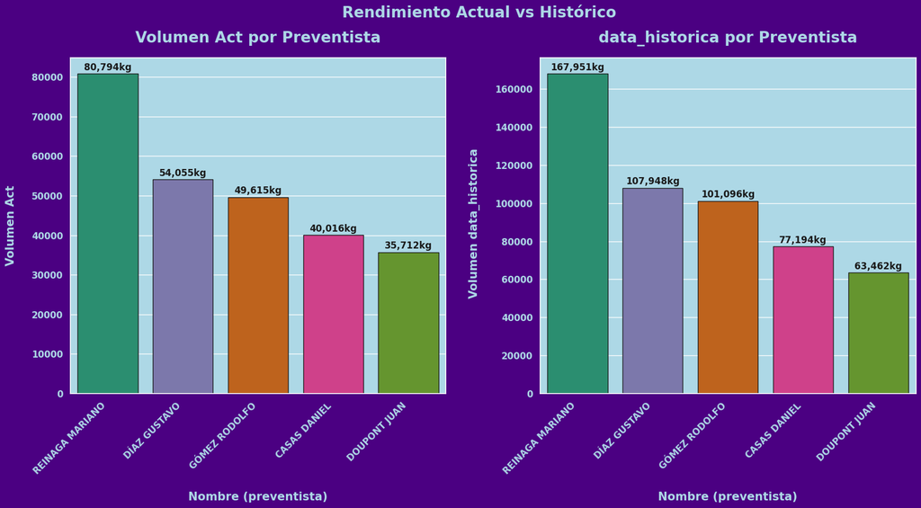

```python
sns.set_style('darkgrid')
sns.set_theme(rc={'axes.facecolor':'lightblue', 'figure.facecolor':'indigo'})
plt.figure(figsize=(20,8))
plt.subplot(1,2,1)
plt.suptitle('Rendimiento Actual vs Histórico', color='lightblue', size=20, weight='bold', y=1)
ax = sns.barplot(x='Nombre (preventista)', y='Volumen Act', data=rendimiento_actual_historico_promedio, edgecolor='k', hue='promedio_rendimiento_actual_historico', palette='Dark2')
plt.title('Volumen Act por Preventista', color='lightblue', size=20, weight='bold', pad=20)
plt.xlabel('Nombre (preventista)', color='lightblue', size=15, weight='bold', labelpad=20)
plt.ylabel('Volumen Act', color='lightblue', size=15, weight='bold', labelpad=20)
plt.xticks(color='lightblue', size=12, weight='bold', rotation=45, ha='right')
plt.yticks(color='lightblue', size=12, weight='bold')
for container in ax.containers:
    ax.bar_label(container,
                 label_type='edge',
                 padding=2,
                 color='k',
                 fontsize=12,
                 fontweight='bold',
                 fmt='{:,.0f}kg'
  )
plt.legend().remove()
plt.subplot(1,2,2)
ax = sns.barplot(x='Nombre (preventista)', y='data_historica', data=rendimiento_actual_historico_promedio, edgecolor='k', hue='promedio_rendimiento_actual_historico', palette='Dark2')
plt.title('data_historica por Preventista', color='lightblue', size=20, weight='bold', pad=20)
plt.xlabel('Nombre (preventista)', color='lightblue', size=15, weight='bold', labelpad=20)
plt.ylabel(' Volumen data_historica', color='lightblue', size=15, weight='bold', labelpad=20)
plt.xticks(color='lightblue', size=12, weight='bold', rotation=45, ha='right')
plt.yticks(color='lightblue', size=12, weight='bold')
for container in ax.containers:
    ax.bar_label(container,
                 label_type='edge',
                 padding=2,
                 color='k',
                 fontsize=12,
                 fontweight='bold',
                 fmt='{:,.0f}kg'
  )
plt.legend().remove()
plt.subplots_adjust(wspace=0.25)
plt.show()
```

### 4. **Análisis de rendimiento por preventista**

- **Mayores y menores resultados:** Identificaré quiénes son los mayores y los menores resultados en términos de:
  - **Volumen total** (columna **Volumen Act**).
  - **Desempeño en la variación de meses** (columna **% Var Volumen Mes**). Esto me ayudará a ver quién ha logrado el mayor crecimiento en comparación con el mes anterior.
  - **Desviaciones actuales** (columna **% Dev Actual**): Analizaré si alguno de los preventistas está fuera de los márgenes aceptables o si destaca por su consistencia.

```python
data2.head()
```

|  | Nombre (preventista) | Volumen Act | Prom Actual | Volumen Mes Julio | Prom Julio | % Var Volumen Mes-2 | Volumen Mes Septiem | Prom Septiem | % Var Volumen Mes | % Dev Actual |
| --- | --- | --- | --- | --- | --- | --- | --- | --- | --- | --- |
| 0 | REINAGA MARIANO | 80794 | 3366 | 89264 | 3719 | -9.5 | 78687 | 2636 | 2.7 | 1.1 |
| 1 | DÍAZ GUSTAVO | 54055 | 2252 | 56019 | 2334 | -3.5 | 51929 | 1667 | 4.1 | 1.1 |
| 2 | GÓMEZ RODOLFO | 49615 | 2067 | 51900 | 2163 | -4.4 | 49196 | 1644 | 0.9 | 1.2 |
| 3 | CASAS DANIEL | 40016 | 1667 | 40728 | 1697 | -1.7 | 36466 | 1358 | 9.7 | 3.2 |
| 4 | DOUPONT JUAN | 35712 | 1488 | 33132 | 1380 | 7.8 | 30330 | 861 | 17.7 | 1.9 |

```python
rendimineto_por_volumen = data2.loc[:,['Nombre (preventista)','Volumen Act','% Var Volumen Mes','% Dev Actual']].sort_values(by='Volumen Act', ascending=False)
rendimineto_por_volumen
```

|  | Nombre (preventista) | Volumen Act | % Var Volumen Mes | % Dev Actual |
| --- | --- | --- | --- | --- |
| 0 | REINAGA MARIANO | 80794 | 2.7 | 1.1 |
| 1 | DÍAZ GUSTAVO | 54055 | 4.1 | 1.1 |
| 2 | GÓMEZ RODOLFO | 49615 | 0.9 | 1.2 |
| 3 | CASAS DANIEL | 40016 | 9.7 | 3.2 |
| 4 | DOUPONT JUAN | 35712 | 17.7 | 1.9 |

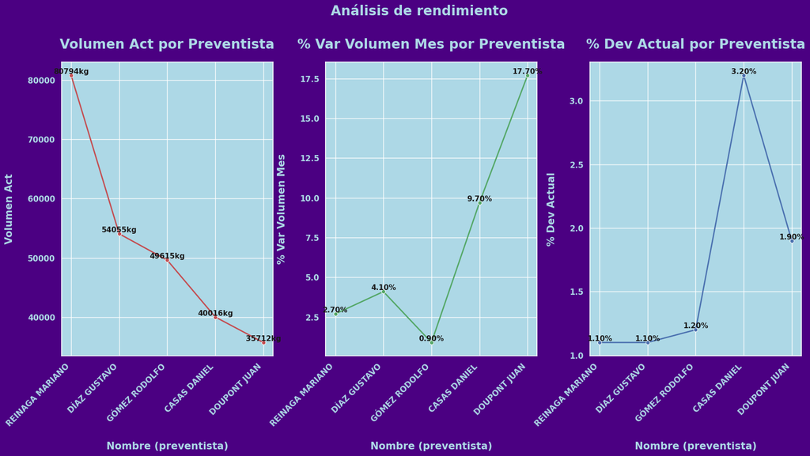

```python
sns.set_style('darkgrid')
sns.set_theme(rc={'axes.facecolor': 'lightblue', 'figure.facecolor': 'indigo'})
plt.figure(figsize=(20, 8))
plt.suptitle('Análisis de rendimiento', color='lightblue', size=20, weight='bold', y=1.03)

# Subplot 1: Volumen Act por Preventista
plt.subplot(1, 3, 1)
plot1 = sns.lineplot(x='Nombre (preventista)', y='Volumen Act', data=rendimineto_por_volumen, marker='o', color='r', linewidth=2)
plt.title('Volumen Act por Preventista', color='lightblue', size=20, weight='bold', pad=20)
plt.xlabel('Nombre (preventista)', color='lightblue', size=15, weight='bold', labelpad=20)
plt.ylabel('Volumen Act', color='lightblue', size=15, weight='bold', labelpad=20)
plt.xticks(color='lightblue', size=12, weight='bold', rotation=45, ha='right')
plt.yticks(color='lightblue', size=12, weight='bold')

# Agregar etiquetas de valores en los puntos de la línea del primer gráfico
for x, y in zip(rendimineto_por_volumen['Nombre (preventista)'], rendimineto_por_volumen['Volumen Act']):
    plt.text(x, y, f'{y:.0f}kg', color='k', ha='center', va='bottom', fontweight='bold',fontsize=11)

# Subplot 2: % Var Volumen Mes por Preventista
plt.subplot(1, 3, 2)
plot2 = sns.lineplot(x='Nombre (preventista)', y='% Var Volumen Mes', data=rendimineto_por_volumen, marker='o', color='g', linewidth=2)
plt.title('% Var Volumen Mes por Preventista', color='lightblue', size=20, weight='bold', pad=20)
plt.xlabel('Nombre (preventista)', color='lightblue', size=15, weight='bold', labelpad=20)
plt.ylabel('% Var Volumen Mes', color='lightblue', size=15, weight='bold', labelpad=20)
plt.xticks(color='lightblue', size=12, weight='bold', rotation=45, ha='right')
plt.yticks(color='lightblue', size=12, weight='bold')

# Agregar etiquetas de valores en los puntos de la línea del segundo gráfico
for x, y in zip(rendimineto_por_volumen['Nombre (preventista)'], rendimineto_por_volumen['% Var Volumen Mes']):
    plt.text(x, y, f'{y:.2f}%', color='k', ha='center', va='bottom', fontweight='bold',fontsize=11)

# Subplot 3: % Dev Actual por Preventista
plt.subplot(1, 3, 3)
plot3 = sns.lineplot(x='Nombre (preventista)', y='% Dev Actual', data=rendimineto_por_volumen, marker='o', color='b', linewidth=2)
plt.title('% Dev Actual por Preventista', color='lightblue', size=20, weight='bold', pad=20)
plt.xlabel('Nombre (preventista)', color='lightblue', size=15, weight='bold', labelpad=20)
plt.ylabel('% Dev Actual', color='lightblue', size=15, weight='bold', labelpad=20)
plt.xticks(color='lightblue', size=12, weight='bold', rotation=45, ha='right')
plt.yticks(color='lightblue', size=12, weight='bold')

# Agregar etiquetas de valores en los puntos de la línea del tercer gráfico
for x, y in zip(rendimineto_por_volumen['Nombre (preventista)'], rendimineto_por_volumen['% Dev Actual']):
    plt.text(x, y, f'{y:.2f}%', color='k', ha='center', va='bottom', fontweight='bold',fontsize=11)

plt.subplots_adjust(wspace=0.25)
plt.show()
```

### 5. **Visualización de datos**

- **Gráficos de barras:** Representaré el volumen de ventas de cada preventista en diferentes meses mediante gráficos de barras. Esto me permitirá identificar visualmente quién está destacando y quién necesita mejorar.
- **Gráfico de líneas:** Haré un gráfico de líneas para trazar las tendencias de crecimiento o decrecimiento en el volumen de ventas a lo largo del tiempo, resaltando **Julio** y **Septiembre**.
- **Mapa de calor:** Crearé un mapa de calor para las variaciones porcentuales, lo cual me ayudará a identificar rápidamente qué preventistas están experimentando mayores fluctuaciones.

```python
data2.sample()
```

|  | Nombre (preventista) | Volumen Act | Prom Actual | Volumen Mes Julio | Prom Julio | % Var Volumen Mes-2 | Volumen Mes Septiem | Prom Septiem | % Var Volumen Mes | % Dev Actual |
| --- | --- | --- | --- | --- | --- | --- | --- | --- | --- | --- |
| 2 | GÓMEZ RODOLFO | 49615 | 2067 | 51900 | 2163 | -4.4 | 49196 | 1644 | 0.9 | 1.2 |

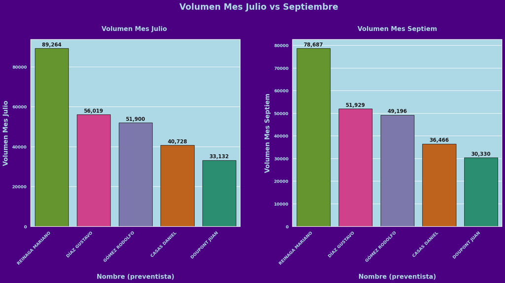

```python
sns.set_style('darkgrid')
sns.set_theme(rc={'axes.facecolor':'lightblue', 'figure.facecolor':'indigo'})
plt.figure(figsize=(20,8))
plt.suptitle('Volumen Mes Julio vs Septiembre', color='lightblue', size=20, weight='bold', y=1.03)
plt.subplot(1,2,1)
ax = sns.barplot(x='Nombre (preventista)', y='Volumen Mes Julio', data=data2, edgecolor='k', hue='Volumen Mes Julio', palette='Dark2')
plt.title('Volumen Mes Julio ', color='lightblue', size=15, weight='bold', pad=20)
plt.xlabel('Nombre (preventista)', color='lightblue', size=15, weight='bold', labelpad=20)
plt.ylabel('Volumen Mes Julio', color='lightblue', size=15, weight='bold', labelpad=7)
plt.xticks(color='lightblue', size=10, weight='bold', rotation=45, ha='right')
plt.yticks(color='lightblue', size=10, weight='bold')
for container in ax.containers:
    ax.bar_label(container,
                label_type='edge',
                padding=2,
                color='k',
                fontsize=12,
                fontweight='bold',
                fmt='{:,.0f}'
                )
plt.legend().remove()
plt.subplot(1,2,2)
ax = sns.barplot(x='Nombre (preventista)', y='Volumen Mes Septiem', data=data2, edgecolor='k', hue='Volumen Mes Septiem', palette='Dark2')
plt.title('Volumen Mes Septiem', color='lightblue', size=15, weight='bold', pad=20)
plt.xlabel('Nombre (preventista)', color='lightblue', size=15, weight='bold', labelpad=20)
plt.ylabel('Volumen Mes Septiem', color='lightblue', size=15, weight='bold', labelpad=7)
plt.xticks(color='lightblue', size=10, weight='bold', rotation=45, ha='right')
plt.yticks(color='lightblue', size=10, weight='bold')
for container in ax.containers:
      ax.bar_label(container,
                                label_type='edge',
                                padding=2,
                                color='k',
                                fontsize=12,
                                fontweight='bold',
                                fmt='{:,.0f}'
                                )
plt.legend().remove()
plt.subplots_adjust(wspace=0.25)
plt.show()
```

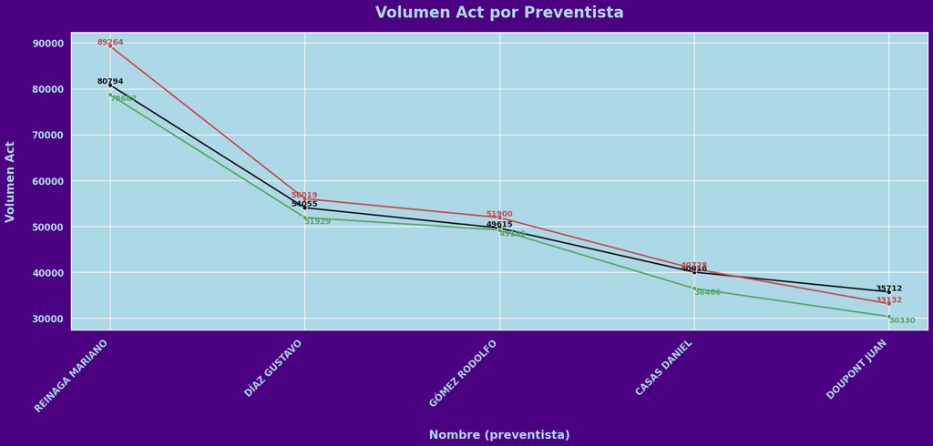

```python
sns.set_style('darkgrid')
sns.set_theme(rc={'axes.facecolor':'lightblue', 'figure.facecolor':'indigo'})
plt.figure(figsize=(20,7))
sns.lineplot(data=data2, x='Nombre (preventista)', y='Volumen Act', marker='o', color='k', linewidth=2)
sns.lineplot(data=data2, x='Nombre (preventista)', y='Volumen Mes Julio', marker='o', color='r', linewidth=2)
sns.lineplot(data=data2, x='Nombre (preventista)', y='Volumen Mes Septiem', marker='o', color='g', linewidth=2)
plt.title('Volumen Act por Preventista', color='lightblue', size=20, weight='bold', pad=20)
plt.xlabel('Nombre (preventista)', color='lightblue', size=15, weight='bold', labelpad=20)
plt.ylabel('Volumen Act', color='lightblue', size=15, weight='bold', labelpad=20)
plt.xticks(color='lightblue', size=12, weight='bold', rotation=45, ha='right')
plt.yticks(color='lightblue', size=12, weight='bold')
for x, y in zip(data2['Nombre (preventista)'], data2['Volumen Act']):
    plt.text(x, y, f'{y:.0f}', color='k', ha='center', va='bottom', fontweight='bold', fontsize=10)
for x, y in zip(data2['Nombre (preventista)'], data2['Volumen Mes Julio']):
    plt.text(x, y, f'{y:.0f}', color='r', ha='center', va='bottom', fontweight='bold', fontsize=10)
for x, y in zip(data2['Nombre (preventista)'], data2['Volumen Mes Septiem']):
    plt.text(x, y, f'{y:.0f}', color='g', ha='left', va='top', fontweight='bold', fontsize=10)
plt.show()
```

```python
porcentuales = data2.loc[:,['Nombre (preventista)','% Var Volumen Mes','% Dev Actual','% Var Volumen Mes-2']]
porcentuales
```

|  | Nombre (preventista) | % Var Volumen Mes | % Dev Actual | % Var Volumen Mes-2 |
| --- | --- | --- | --- | --- |
| 0 | REINAGA MARIANO | 2.7 | 1.1 | -9.5 |
| 1 | DÍAZ GUSTAVO | 4.1 | 1.1 | -3.5 |
| 2 | GÓMEZ RODOLFO | 0.9 | 1.2 | -4.4 |
| 3 | CASAS DANIEL | 9.7 | 3.2 | -1.7 |
| 4 | DOUPONT JUAN | 17.7 | 1.9 | 7.8 |

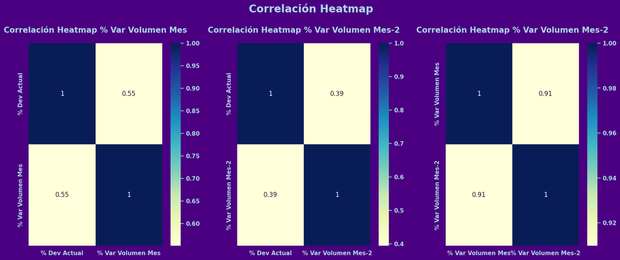

```python
sns.set_style('darkgrid')
sns.set_theme(rc={'axes.facecolor':'lightblue', 'figure.facecolor':'indigo'})
plt.figure(figsize=(20,7))
plt.suptitle('Correlación Heatmap', color='lightblue', size=20, weight='bold', y=1.03)
plt.subplot(1,3,1)
heatmap = sns.heatmap(porcentuales[['% Dev Actual','% Var Volumen Mes']].corr(), annot=True, cmap='YlGnBu')
cbar = heatmap.collections[0].colorbar
cbar.ax.yaxis.set_tick_params(color='lightblue')
plt.setp(cbar.ax.yaxis.get_ticklabels(), color='lightblue', weight='bold')
plt.title('Correlación Heatmap % Var Volumen Mes', color='lightblue', size=15, weight='bold', pad=20)
plt.xticks(color='lightblue', size=11, weight='bold')
plt.yticks(color='lightblue', size=11, weight='bold')
plt.subplot(1,3,2)
heatmap = sns.heatmap(porcentuales[['% Dev Actual','% Var Volumen Mes-2']].corr(), annot=True, cmap='YlGnBu')
cbar = heatmap.collections[0].colorbar
cbar.ax.yaxis.set_tick_params(color='lightblue')
plt.setp(cbar.ax.yaxis.get_ticklabels(), color='lightblue', weight='bold')
plt.title('Correlación Heatmap % Var Volumen Mes-2', color='lightblue', size=15, weight='bold', pad=20)
plt.xticks(color='lightblue', size=11, weight='bold')
plt.yticks(color='lightblue', size=11, weight='bold')
plt.subplot(1,3,3)
heatmap = sns.heatmap(porcentuales[['% Var Volumen Mes','% Var Volumen Mes-2']].corr(), annot=True, cmap='YlGnBu')
cbar = heatmap.collections[0].colorbar
cbar.ax.yaxis.set_tick_params(color='lightblue')
plt.setp(cbar.ax.yaxis.get_ticklabels(), color='lightblue', weight='bold')
plt.title('Correlación Heatmap % Var Volumen Mes-2', color='lightblue', size=15, weight='bold', pad=20)
plt.xticks(color='lightblue', size=11, weight='bold')
plt.yticks(color='lightblue', size=11, weight='bold')
plt.subplots_adjust(wspace=0.25)
plt.show()
```

### 6. **Análisis de correlaciones**

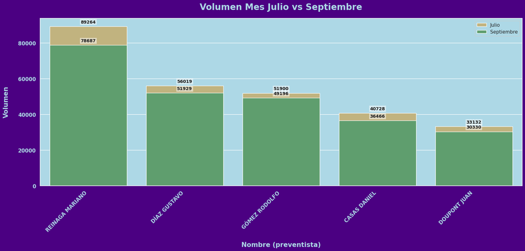

```python
sns.set_style('darkgrid')
sns.set_theme(rc={'axes.facecolor':'lightblue', 'figure.facecolor':'indigo'})
plt.figure(figsize=(20,7))
ax1 = sns.barplot(data=data2, x='Nombre (preventista)', y='Volumen Mes Julio', color='y', label='Julio')
ax2 = sns.barplot(data=data2, x='Nombre (preventista)', y='Volumen Mes Septiem', color='g', label='Septiembre')
def add_value_labels(ax, spacing=5):
    for container in ax.containers:
        ax.bar_label(container,
                    fmt='%.0f',  # Sin decimales
                    label_type='edge',  # Coloca las etiquetas en el borde superior
                    padding=spacing,  # Espacio entre la barra y el valor
                    fontsize=10,
                    fontweight='bold',
                    bbox=dict(facecolor='w',
                            edgecolor='none',
                            alpha=0.3,  # Semi-transparente
                            pad=2),  # Fondo blanco para mejor legibilidad
                    rotation=0)
add_value_labels(ax1)
add_value_labels(ax2)
plt.title('Volumen Mes Julio vs Septiembre', color='lightblue', size=20, weight='bold', pad=20)
plt.xlabel('Nombre (preventista)', color='lightblue', size=15, weight='bold', labelpad=20)
plt.ylabel('Volumen', color='lightblue', size=15, weight='bold', labelpad=20)
plt.xticks(color='lightblue', size=12, weight='bold', rotation=45, ha='right')
plt.yticks(color='lightblue', size=12, weight='bold')
plt.show()
```

### 7. **Conclusiones y recomendaciones**

- **Detectar áreas de mejora:** Identificaré preventistas con baja variación positiva o con resultados consistentemente inferiores al promedio. De esta manera, podré enfocar estrategias de mejora en ellos.
- **Destacar buenos resultados:** Si algún preventista muestra un crecimiento constante o un buen desempeño, investigaré qué está haciendo bien para replicar esos métodos con otros equipos.

```python
data2.sample()
```

|  | Nombre (preventista) | Volumen Act | Prom Actual | Volumen Mes Julio | Prom Julio | % Var Volumen Mes-2 | Volumen Mes Septiem | Prom Septiem | % Var Volumen Mes | % Dev Actual |
| --- | --- | --- | --- | --- | --- | --- | --- | --- | --- | --- |
| 0 | REINAGA MARIANO | 80794 | 3366 | 89264 | 3719 | -9.5 | 78687 | 2636 | 2.7 | 1.1 |

Calcular la variación positiva: Calcula la variación positiva de cada preventista utilizando la fórmula: (resultado actual - resultado anterior) / resultado anterior. Puedes hacer esto utilizando la función pandas.DataFrame.diff().

Identificar preventistas con baja variación positiva: Utiliza una condición para identificar los preventistas con una variación positiva menor a un umbral determinado (por ejemplo, 0.1). Puedes hacer esto utilizando la función pandas.DataFrame.loc[].

Identificar preventistas con resultados consistentemente inferiores al promedio: Calcula el promedio de los resultados de cada preventista utilizando la función pandas.DataFrame.mean(). Luego, identifica los preventistas cuyos resultados son consistentemente inferiores al promedio utilizando una condición.

```python
data2['Variación_porcentual_actual_vs_Julio'] = ((data2['Volumen Act'] - data2['Volumen Mes Julio']) / data2['Volumen Mes Julio'])*100
data2
```

|  | Nombre (preventista) | Volumen Act | Prom Actual | Volumen Mes Julio | Prom Julio | % Var Volumen Mes-2 | Volumen Mes Septiem | Prom Septiem | % Var Volumen Mes | % Dev Actual | Variación_porcentual_actual_vs_Julio |
| --- | --- | --- | --- | --- | --- | --- | --- | --- | --- | --- | --- |
| 0 | REINAGA MARIANO | 80794 | 3366 | 89264 | 3719 | -9.5 | 78687 | 2636 | 2.7 | 1.1 | -9.488708 |
| 1 | DÍAZ GUSTAVO | 54055 | 2252 | 56019 | 2334 | -3.5 | 51929 | 1667 | 4.1 | 1.1 | -3.505953 |
| 2 | GÓMEZ RODOLFO | 49615 | 2067 | 51900 | 2163 | -4.4 | 49196 | 1644 | 0.9 | 1.2 | -4.402697 |
| 3 | CASAS DANIEL | 40016 | 1667 | 40728 | 1697 | -1.7 | 36466 | 1358 | 9.7 | 3.2 | -1.748183 |
| 4 | DOUPONT JUAN | 35712 | 1488 | 33132 | 1380 | 7.8 | 30330 | 861 | 17.7 | 1.9 | 7.787034 |

```python
data2['Variación_porcentual_actual_vs_septiembre'] = ((data2['Volumen Act'] - data2['Volumen Mes Septiem']) / data2['Volumen Mes Septiem'])*100
data2
```

|  | Nombre (preventista) | Volumen Act | Prom Actual | Volumen Mes Julio | Prom Julio | % Var Volumen Mes-2 | Volumen Mes Septiem | Prom Septiem | % Var Volumen Mes | % Dev Actual | Variación_porcentual_actual_vs_Julio | Variación_porcentual_actual_vs_septiembre |
| --- | --- | --- | --- | --- | --- | --- | --- | --- | --- | --- | --- | --- |
| 0 | REINAGA MARIANO | 80794 | 3366 | 89264 | 3719 | -9.5 | 78687 | 2636 | 2.7 | 1.1 | -9.488708 | 2.677698 |
| 1 | DÍAZ GUSTAVO | 54055 | 2252 | 56019 | 2334 | -3.5 | 51929 | 1667 | 4.1 | 1.1 | -3.505953 | 4.094051 |
| 2 | GÓMEZ RODOLFO | 49615 | 2067 | 51900 | 2163 | -4.4 | 49196 | 1644 | 0.9 | 1.2 | -4.402697 | 0.851695 |
| 3 | CASAS DANIEL | 40016 | 1667 | 40728 | 1697 | -1.7 | 36466 | 1358 | 9.7 | 3.2 | -1.748183 | 9.735096 |
| 4 | DOUPONT JUAN | 35712 | 1488 | 33132 | 1380 | 7.8 | 30330 | 861 | 17.7 | 1.9 | 7.787034 | 17.744807 |

```python
data2
```

|  | Nombre (preventista) | Volumen Act | Prom Actual | Volumen Mes Julio | Prom Julio | % Var Volumen Mes-2 | Volumen Mes Septiem | Prom Septiem | % Var Volumen Mes | % Dev Actual | Variación_porcentual_actual_vs_Julio | Variación_porcentual_actual_vs_septiembre |
| --- | --- | --- | --- | --- | --- | --- | --- | --- | --- | --- | --- | --- |
| 0 | REINAGA MARIANO | 80794 | 3366 | 89264 | 3719 | -9.5 | 78687 | 2636 | 2.7 | 1.1 | -9.488708 | 2.677698 |
| 1 | DÍAZ GUSTAVO | 54055 | 2252 | 56019 | 2334 | -3.5 | 51929 | 1667 | 4.1 | 1.1 | -3.505953 | 4.094051 |
| 2 | GÓMEZ RODOLFO | 49615 | 2067 | 51900 | 2163 | -4.4 | 49196 | 1644 | 0.9 | 1.2 | -4.402697 | 0.851695 |
| 3 | CASAS DANIEL | 40016 | 1667 | 40728 | 1697 | -1.7 | 36466 | 1358 | 9.7 | 3.2 | -1.748183 | 9.735096 |
| 4 | DOUPONT JUAN | 35712 | 1488 | 33132 | 1380 | 7.8 | 30330 | 861 | 17.7 | 1.9 | 7.787034 | 17.744807 |

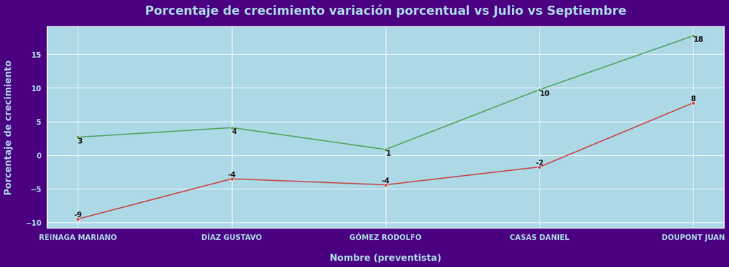

```python
sns.set_style('darkgrid')
sns.set_theme(rc={'axes.facecolor':'lightblue', 'figure.facecolor':'indigo'})
plt.figure(figsize=(20,6))
sns.lineplot(data=data2, x='Nombre (preventista)', y='Variación_porcentual_actual_vs_Julio', marker='o', color='r', linewidth=2)
sns.lineplot(data=data2, x='Nombre (preventista)', y='Variación_porcentual_actual_vs_septiembre', marker='o', color='g', linewidth=2)
plt.title('Porcentaje de crecimiento variación porcentual vs Julio vs Septiembre', color='lightblue', size=20, weight='bold', pad=20)
plt.xlabel('Nombre (preventista)', color='lightblue', size=15, weight='bold', labelpad=20)
plt.ylabel('Porcentaje de crecimiento', color='lightblue', size=15, weight='bold', labelpad=20)
plt.xticks(color='lightblue', size=12, weight='bold')
plt.yticks(color='lightblue', size=12, weight='bold')
for x, y in zip(data2['Nombre (preventista)'], data2['Variación_porcentual_actual_vs_Julio']):
    plt.text(x, y, f'{y:.0f}', color='k', ha='center', va='bottom', fontweight='bold', fontsize=12)
for x, y in zip(data2['Nombre (preventista)'], data2['Variación_porcentual_actual_vs_septiembre']):
    plt.text(x, y, f'{y:.0f}', color='k', ha='left', va='top', fontweight='bold', fontsize=12)
plt.show()
```

Resumen Ejecutivo de Análisis de Ventas por Preventista Este documento presenta un análisis detallado del rendimiento de ventas de los preventistas, basado en datos de Julio, Septiembre y el mes actual. El análisis se enfoca en identificar tendencias, patrones y áreas de mejora en el equipo de ventas.

1. Análisis Descriptivo

Se analizaron los valores de volumen de ventas (Volumen Act, Volumen Mes Julio, Volumen Mes Septiem) y se calcularon promedios para identificar el rendimiento general del equipo. Se observó que RINAGA MARIANO lidera en volumen total de ventas actual, mientras que DOUPONT JUAN presenta el mayor porcentaje de crecimiento en el último mes (17.7%).

2. Identificación de Patrones

Se clasificaron los preventistas según su rendimiento, considerando la variación porcentual en el volumen de ventas. Se encontró que la mayoría de los preventistas (REINAGA MARIANO, DIAZ GUSTAVO, CASAS DANIEL y DOUPONT JUAN) muestran una tendencia creciente en sus ventas. GÓMEZ RODOLFO mantiene un desempeño constante.

3. Comparación de Meses

4. Análisis de Rendimiento por Preventista

Se identificaron los preventistas con mayores y menores resultados en términos de volumen total, variación porcentual y desviaciones actuales. REINAGA MARIANO lidera en volumen total, mientras que DOUPONT JUAN destaca por su alto crecimiento porcentual.

5. Visualización de Datos

Se utilizaron gráficos de barras, de líneas y mapas de calor para visualizar las tendencias de ventas y las variaciones porcentuales, facilitando la identificación de patrones y áreas de mejora.

6. Análisis de Correlaciones

7. Conclusiones y Recomendaciones

Se identificaron las siguientes áreas de mejora:

Implementar programas de capacitación para fortalecer las habilidades de venta del equipo, especialmente para aquellos preventistas con bajo rendimiento. Establecer metas de ventas desafiantes pero alcanzables, incentivando la motivación y el crecimiento del equipo. Monitorear continuamente el desempeño de los preventistas, identificando áreas de oportunidad y brindando retroalimentación constante. Celebrar y reconocer los logros de los preventistas, fomentando un ambiente de trabajo positivo y competitivo. Este análisis proporciona información valiosa para la toma de decisiones estratégicas en el área de ventas. Al implementar las recomendaciones, se espera un aumento en la eficiencia y el rendimiento general del equipo.